# Genetic Dependency Detection

Martin Brand

April 6, 2023

We import the libraries.

```r
library(tidyverse)
library(ggplot2)
library(ggrepel)
library(matrixTests)
library(dplyr)
library(cowplot)
library(limma)
library(gridExtra)
```

# Analyzed Genes and Target

We define the genes for classification, the expected target gene and the classification criteria.

```r
gene1 <- "BRAF"
gene2 <- "BRAF"
# target.genes <- c("FUBP1","SF1","U2AF1","U2AF2","SNRPB","SNRPD1","SNRPD2",
#                   "SNRPD3","SNRPE","SNRPF","SNRPG","PUF60","SMNDC1",
#                   "DNAJC8","RBM17","CHERP","U2SURP","DHX15","DDX46","CELF6",
#                   "PCBP1")
# target.genes <- c("PARP1","PARP2")
target.genes <- c("BRAF")
# possible methods: "del.vs.non.del", "del.vs.non.mut","mut.vs.non.mut"
classification.method <- "mut.vs.non.mut"
```

In this analysis, the genes used for classification are BRAF and BRAF. The expected target gene is BRAF.

# Data Preprocessing

We define the directory for the data and helper functions.

```r
data.dir <-
  "C:/Users/Martin/Documents/Master/Thesis/genetic_dependency_detection/data/"
```

We load the dataset that contains CCLE IDs and corresponding DepMap IDs for the cell lines ([DepMapIDs](https://depmap.org/portal/download/all/?releasename=DepMap+Public+18Q3&filename=DepMap-2018q3-celllines.csv)), the dataset that contains the mutation information of the cell lines ([CCLE dataset](https://depmap.org/portal/download/all/?releasename=DepMap+Public+19Q2&filename=CCLE_mutations.csv)) and the datasets that contains the dependency scores from the projects Achilles and DRIVE ([DepMap datasets](https://figshare.com/articles/dataset/DepMap_Datasets_for_WRN_manuscript/7712756/1)).

```r
cancer.names <- read.csv(paste0(data.dir, "DepMap-2018q3-celllines.csv"))
cancer.names <- cancer.names[,c(1,2)]
colnames(cancer.names) <- c("DepMap_ID","CCLE_ID")

CCLE.mut <- read.csv(paste0(data.dir, "CCLE_mutations.csv"))
CCLE.mut <- CCLE.mut[,c(1,8,16,20)]

dep.scores <- read_rds(file.path(data.dir, 'DepMap_18Q4_data.rds'))

dep.scores.DRIVE <- as.data.frame(dep.scores[["DRIVE"]])
dep.scores.DRIVE$CCLE_ID <- rownames(dep.scores.DRIVE)
rownames(dep.scores.DRIVE) <- NULL
dep.scores.DRIVE <- dep.scores.DRIVE %>% select(CCLE_ID, everything())

dep.scores.Achilles <- as.data.frame(dep.scores[["CRISPR"]])
dep.scores.Achilles$CCLE_ID <- rownames(dep.scores.Achilles)
rownames(dep.scores.Achilles) <- NULL
dep.scores.Achilles <- dep.scores.Achilles %>% select(CCLE_ID,everything())

# remove unnecessary objects
rm(dep.scores)

# save important objects
saveRDS(cancer.names,paste0(data.dir,"cancer.names.rds"))
saveRDS(CCLE.mut,paste0(data.dir,"CCLE.mut.rds"))
saveRDS(dep.scores.DRIVE,paste0(data.dir,"dep.scores.DRIVE.rds"))
saveRDS(dep.scores.Achilles,paste0(data.dir,"dep.scores.Achilles.rds"))
```

```r
# load important objects
cancer.names <- readRDS(paste0(data.dir,"cancer.names.rds"))
CCLE.mut <- readRDS(paste0(data.dir,"CCLE.mut.rds"))
dep.scores.DRIVE <- readRDS(paste0(data.dir,"dep.scores.DRIVE.rds"))
dep.scores.Achilles <- readRDS(paste0(data.dir,"dep.scores.Achilles.rds"))
```

We load the helper functions.

```r
# load helper functions
source("helper_functions/create.mutation.counts.plot.R")
source("helper_functions/create.mutation.counts.plot.mark.R")
source("helper_functions/create.classification.table.del.vs.non.del.R")
source("helper_functions/create.classification.table.mut.vs.non.mut.R")
source("helper_functions/create.classification.table.del.vs.non.mut.R")
source("helper_functions/merge.class.tables.R")
source("helper_functions/merge.class.tables.AND.R")
source("helper_functions/create_barcharts_classifications.R")
source("helper_functions/plot.mean.diffs.R")
source("helper_functions/calc.mean.diffs.and.p.values.R")
source("helper_functions/create_volcano_plot.R")
source("helper_functions/create.significant.genes.table.R")
```

# Data Exploration

## Mutation Counts

To find potential genes for classification, we plot the distribution of mutation numbers in the overlapping genes of the CCLE dataset and the datasets DRIVE and Achilles.

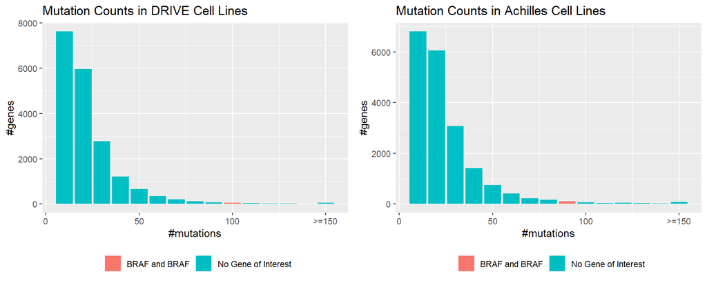

```r
mutation.plot.DRIVE <- create.mutation.counts.plot.mark("DRIVE",dep.scores.DRIVE,
                                                   cancer.names,CCLE.mut)

mutation.plot.Achilles <- create.mutation.counts.plot.mark("Achilles",
                                                      dep.scores.Achilles,
                                                      cancer.names,CCLE.mut)

grid.arrange(mutation.plot.DRIVE,mutation.plot.Achilles,ncol=2)
```

```r
rm(mutation.plot.DRIVE,mutation.plot.Achilles)
```

## Classification Tables for BRAF and BRAF

We create classification tables that show us for each cell line whether the selected genes are deleteriously mutated or not. Therefore we create one table where we check whether BRAF is deleteriously mutated, another table where we do the same for BRAF and a third table where we check whether at least one of BRAF and BRAF is deleteriously mutated.

```r
create.classification.table <- switch(classification.method,
                "del.vs.non.del" = create.classification.table.del.vs.non.del,
                "del.vs.non.mut" = create.classification.table.del.vs.non.mut,
                "mut.vs.non.mut" = create.classification.table.mut.vs.non.mut)

class.table.gene1 <- create.classification.table(
                                                CCLE.mut, cancer.names,
                                                gene1, dep.scores.DRIVE,
                                                dep.scores.Achilles)
class.table.gene2 <- create.classification.table(
                                                CCLE.mut, cancer.names,
                                                gene2, dep.scores.DRIVE,
                                                dep.scores.Achilles)

# merge tables
class.table.comb.DRIVE <- merge.class.tables(class.table.gene1$DRIVE,
                                             class.table.gene2$DRIVE)

class.table.comb.Achilles <- merge.class.tables(class.table.gene1$Achilles,
                                             class.table.gene2$Achilles)

knitr::kable(head(class.table.comb.DRIVE), format = "html",
             table.attr = "style='width:50%;'",
             caption = "Significant Genes in DRIVE")
```

Table 1: Significant Genes in DRIVE

| CCLE_ID | isDeleterious |
| --- | --- |
| 127399_SOFT_TISSUE | FALSE |
| 1321N1_CENTRAL_NERVOUS_SYSTEM | FALSE |
| 2313287_STOMACH | FALSE |
| 697_HAEMATOPOIETIC_AND_LYMPHOID_TISSUE | FALSE |
| 769P_KIDNEY | FALSE |
| 786O_KIDNEY | FALSE |

```r
rm(CCLE.mut,cancer.names)
```

## Classifications for BRAF

To check whether the samples sizes regarding BRAF for the following statistical tests are sufficient, we plot the number of cell lines for both samples.

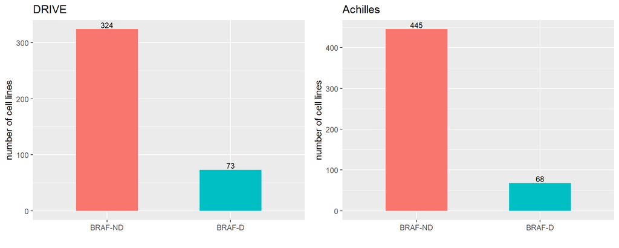

```r
barcharts.gene1 <- create_barcharts_classifications(class.table.gene1$DRIVE,
                                              class.table.gene1$Achilles,
                                              gene1)
plot_grid(barcharts.gene1$DRIVE, barcharts.gene1$Achilles)
```

```r
rm(barcharts.gene1)
```

## Classifications for BRAF

We repeat the plots for BRAF.

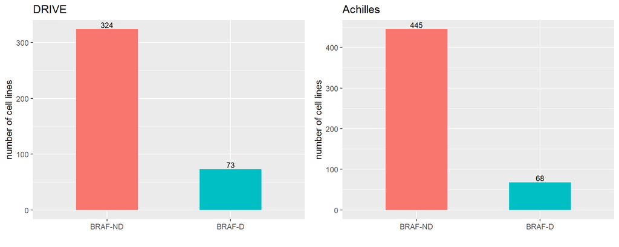

```r
barcharts.gene2 <- create_barcharts_classifications(class.table.gene2$DRIVE,
                                              class.table.gene2$Achilles,
                                              gene2)
plot_grid(barcharts.gene2$DRIVE, barcharts.gene2$Achilles)
```

```r
rm(barcharts.gene2)
```

## Classifications for BRAFand BRAF

We repeat the plots for BRAFand BRAF.

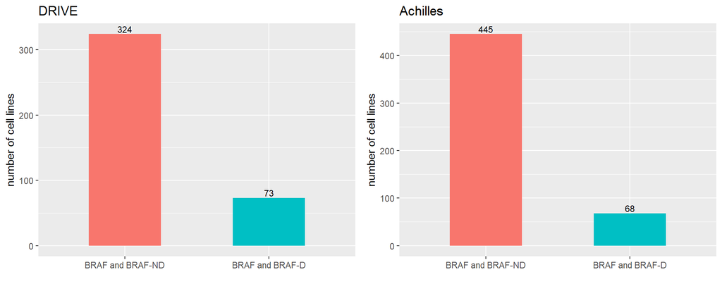

```r
barcharts.comb.genes <- create_barcharts_classifications(class.table.comb.DRIVE,
                                              class.table.comb.Achilles,
                                              paste(gene1,"and",gene2))
plot_grid(barcharts.comb.genes$DRIVE, barcharts.comb.genes$Achilles)
```

```r
rm(barcharts.comb.genes)
```

# Data Analysis BRAF

In order to detect differences between both samples, we compare them for each gene in the datasets DRIVE and Achilles. The workflow was published by [Chan et al., 2019](https://www.nature.com/articles/s41586-019-1102-x).

## Dependency Score Distributions

## Mean Differences

To test whether the two groups respond differently to the knock out or the knock down of a specific gene, we calculate the mean differences between the two groups for each gene.

```r
test.results.gene1 <- calc.mean.diffs.and.p.values(dep.scores.DRIVE,
                                           dep.scores.Achilles,
                                           class.table.gene1$DRIVE,
                                           class.table.gene1$Achilles)

plots <- plot.mean.diffs(test.results.gene1)
grid.arrange(plots$DRIVE,plots$Achilles,ncol=2)
```

[output not shown]

```r
rm(class.table.gene1,plots)
```

## Welch Test

The Welch t-test checks whether the means of two samples are identical. The prerequisite is that both samples are normally distributed, which we have not yet ensured.

```r
plot.welch.DRIVE.gene1 <- create_volcano_plot(test.results.gene1,"DRIVE",
                                              "welch",target.genes,
                                              show_sign_line=T)

plot.welch.Achilles.gene1 <- create_volcano_plot(test.results.gene1,"Achilles",
                                                "welch",target.genes)

grid.arrange(plot.welch.DRIVE.gene1,plot.welch.Achilles.gene1,ncol=2)
```

[output not shown]

```r
rm(plot.welch.DRIVE.gene1,plot.welch.Achilles.gene1)
```

To discover new potential dependencies, the table shows all significant genes.

```r
significant.genes.table.DRIVE.gene1 <- create.significant.genes.table(
  test.results.gene1,"DRIVE","welch")
significant.genes.table.Achilles.gene1 <- create.significant.genes.table(
  test.results.gene1,"Achilles","welch")

knitr::kable(significant.genes.table.DRIVE.gene1, format = "html",
             table.attr = "style='width:50%;'",
             caption = "Significant Genes in DRIVE")
```

Table 2: Significant Genes in DRIVE

|  | gene | p_value | p_adj | log |
| --- | --- | --- | --- | --- |
| 5454 | PTPN11 | 0.0000000 | 0.0000004 | 14.644559 |
| 6065 | SOS1 | 0.0000000 | 0.0000007 | 14.179937 |
| 6104 | BRAF | 0.0000000 | 0.0000236 | 10.654276 |
| 6795 | SHOC2 | 0.0000001 | 0.0001642 | 8.714361 |
| 634 | CLP1 | 0.0000001 | 0.0001823 | 8.609843 |
| 1122 | ADH7 | 0.0000002 | 0.0002055 | 8.490227 |
| 1547 | BMPER | 0.0000002 | 0.0002055 | 8.490227 |
| 7580 | COL23A1 | 0.0000002 | 0.0002055 | 8.490227 |
| 986 | RXFP2 | 0.0000006 | 0.0003459 | 7.969467 |
| 1366 | CBWD2&CBWD5&CBWD3&CBWD6 | 0.0000005 | 0.0003459 | 7.969467 |
| 1693 | ARID2 | 0.0000005 | 0.0003459 | 7.969467 |
| 1726 | FOXD4L1 | 0.0000005 | 0.0003459 | 7.969467 |
| 2370 | CFAP65 | 0.0000004 | 0.0003459 | 7.969467 |
| 4137 | NFE2L2 | 0.0000007 | 0.0004206 | 7.773925 |
| 4967 | PPP6C | 0.0000008 | 0.0004226 | 7.769193 |
| 6003 | NCF1C | 0.0000008 | 0.0004226 | 7.769193 |
| 6072 | SOX10 | 0.0000010 | 0.0004453 | 7.716827 |
| 7897 | CDK1 | 0.0000010 | 0.0004453 | 7.716827 |
| 3828 | LYN | 0.0000015 | 0.0006114 | 7.399735 |
| 2386 | GABRB1 | 0.0000017 | 0.0006353 | 7.361344 |
| 5309 | ATP10A | 0.0000017 | 0.0006353 | 7.361344 |
| 5530 | RAF1 | 0.0000018 | 0.0006353 | 7.361344 |
| 308 | SF3A1 | 0.0000022 | 0.0007374 | 7.212340 |
| 3262 | HTR2C | 0.0000022 | 0.0007374 | 7.212340 |
| 86 | NT5C1B-RDH14&RDH14 | 0.0000025 | 0.0007714 | 7.167323 |
| 6325 | C4BPA | 0.0000025 | 0.0007714 | 7.167323 |
| 5877 | ANAPC1 | 0.0000030 | 0.0008751 | 7.041123 |
| 881 | SLC5A11 | 0.0000035 | 0.0009401 | 6.969499 |
| 6777 | PDGFD | 0.0000034 | 0.0009401 | 6.969499 |
| 7313 | PEA15 | 0.0000034 | 0.0009401 | 6.969499 |

[output cut: 882 more lines]

```r
knitr::kable(significant.genes.table.Achilles.gene1, format = "html",
             table.attr = "style='width:50%;'",
             caption = "Significant Genes in Achilles")
```

Table 2: Significant Genes in Achilles

|  | gene | p_value | p_adj | log |
| --- | --- | --- | --- | --- |
| 1473 | BRAF | 0.00e+00 | 0.0000000 | 17.743627 |
| 6240 | GRB2 | 1.00e-07 | 0.0003799 | 7.875705 |
| 8665 | MAPK1 | 1.00e-07 | 0.0003799 | 7.875705 |
| 12166 | PTPN11 | 1.00e-07 | 0.0003799 | 7.875705 |
| 13625 | SHOC2 | 1.00e-07 | 0.0003799 | 7.875705 |
| 4899 | EXT1 | 3.00e-06 | 0.0072669 | 4.924431 |
| 9011 | MITF | 3.00e-06 | 0.0072669 | 4.924431 |
| 14324 | SOX9 | 3.30e-06 | 0.0072669 | 4.924431 |
| 11115 | PEA15 | 3.90e-06 | 0.0075934 | 4.880482 |
| 16999 | ZDHHC19 | 4.90e-06 | 0.0086648 | 4.748487 |
| 14308 | SOX10 | 8.90e-06 | 0.0142912 | 4.248111 |
| 4381 | DUSP4 | 1.21e-05 | 0.0177572 | 4.030965 |
| 5393 | FGFR1 | 1.44e-05 | 0.0181259 | 4.010413 |
| 8633 | MAP2K1 | 1.44e-05 | 0.0181259 | 4.010413 |
| 17434 | ZNF654 | 1.80e-05 | 0.0211294 | 3.857091 |
| 2080 | CA3 | 2.05e-05 | 0.0225000 | 3.794238 |
| 10611 | OR6B1 | 2.24e-05 | 0.0225000 | 3.794238 |
| 11289 | PIGP | 2.30e-05 | 0.0225000 | 3.794238 |
| 7732 | KIR2DL4 | 2.62e-05 | 0.0234848 | 3.751400 |
| 13090 | RTEL1 | 2.66e-05 | 0.0234848 | 3.751400 |
| 14104 | SMAD4 | 3.54e-05 | 0.0271038 | 3.608083 |
| 16887 | YRDC | 3.53e-05 | 0.0271038 | 3.608083 |
| 17126 | ZNF148 | 3.27e-05 | 0.0271038 | 3.608083 |
| 8042 | LAMB4 | 4.86e-05 | 0.0342611 | 3.373746 |
| 9558 | NACA | 4.79e-05 | 0.0342611 | 3.373746 |
| 14040 | SLC7A6 | 5.74e-05 | 0.0389299 | 3.245992 |
| 3404 | CPED1 | 6.35e-05 | 0.0414709 | 3.182763 |
| 16614 | VPS53 | 6.63e-05 | 0.0417730 | 3.175505 |
| 722 | AOC3 | 7.37e-05 | 0.0420445 | 3.169027 |
| 9020 | MKRN1 | 7.33e-05 | 0.0420445 | 3.169027 |
| 17395 | ZNF592 | 7.39e-05 | 0.0420445 | 3.169027 |
| 378 | AGBL3 | 8.25e-05 | 0.0454361 | 3.091447 |
| 17013 | ZEB2 | 8.55e-05 | 0.0456686 | 3.086345 |
| 4903 | EXTL3 | 9.45e-05 | 0.0490324 | 3.015274 |
| 9800 | NFIX | 9.90e-05 | 0.0498765 | 2.998205 |

```r
rm(significant.genes.table.DRIVE.gene1,significant.genes.table.Achilles.gene1)
```

## Wilcoxon Test

The Wilcoxon test checks whether, for randomly selected values X and Y from two samples, the probability of X being greater than Y is equal to the probability of Y being greater than X. The prerequisite is that the data are ordinary, which is fulfilled here.

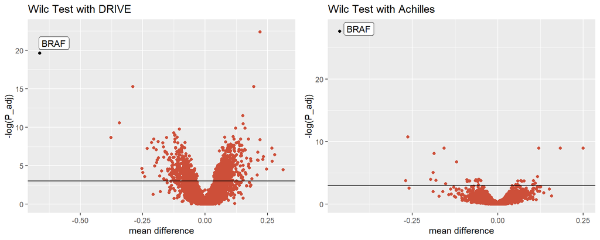

```r
plot.wilc.DRIVE.gene1 <- create_volcano_plot(test.results.gene1,"DRIVE","wilc",
                                       target.genes, show_sign_line=T)

plot.wilc.Achilles.gene1 <- create_volcano_plot(test.results.gene1,"Achilles",
                                                "wilc",target.genes)

grid.arrange(plot.wilc.DRIVE.gene1,plot.wilc.Achilles.gene1,ncol=2)
```

```r
rm(plot.wilc.DRIVE.gene1,plot.wilc.Achilles.gene1)
```

```r
significant.genes.table.DRIVE.gene1 <- create.significant.genes.table(
  test.results.gene1,"DRIVE","wilc")
significant.genes.table.Achilles.gene1 <- create.significant.genes.table(
  test.results.gene1,"Achilles","wilc")

knitr::kable(significant.genes.table.DRIVE.gene1, format = "html",
             table.attr = "style='width:50%;'",
             caption = "Significant Genes in DRIVE")
```

Table 3: Significant Genes in DRIVE

|  | gene | p_value | p_adj | log |
| --- | --- | --- | --- | --- |
| 5454 | PTPN11 | 0.0000000 | 0.0000000 | 22.378066 |
| 6104 | BRAF | 0.0000000 | 0.0000000 | 19.611794 |
| 6065 | SOS1 | 0.0000000 | 0.0000002 | 15.268958 |
| 7313 | PEA15 | 0.0000000 | 0.0000002 | 15.268958 |
| 6003 | NCF1C | 0.0000000 | 0.0000103 | 11.486883 |
| 4967 | PPP6C | 0.0000000 | 0.0000256 | 10.572580 |
| 1122 | ADH7 | 0.0000000 | 0.0000285 | 10.465122 |
| 1693 | ARID2 | 0.0000001 | 0.0000512 | 9.879934 |
| 5309 | ATP10A | 0.0000001 | 0.0000512 | 9.879934 |
| 3262 | HTR2C | 0.0000001 | 0.0000579 | 9.756649 |
| 5350 | PTK2 | 0.0000001 | 0.0000946 | 9.265446 |
| 1726 | FOXD4L1 | 0.0000002 | 0.0001270 | 8.971168 |
| 1366 | CBWD2&CBWD5&CBWD3&CBWD6 | 0.0000002 | 0.0001283 | 8.960925 |
| 6795 | SHOC2 | 0.0000003 | 0.0001546 | 8.774609 |
| 1715 | ELF1 | 0.0000003 | 0.0001631 | 8.721274 |
| 2220 | ICMT | 0.0000003 | 0.0001631 | 8.721274 |
| 6072 | SOX10 | 0.0000004 | 0.0001718 | 8.669378 |
| 881 | SLC5A11 | 0.0000004 | 0.0001737 | 8.658353 |
| 640 | METAP2 | 0.0000006 | 0.0002091 | 8.472871 |
| 929 | SH2D1B | 0.0000006 | 0.0002091 | 8.472871 |
| 5313 | VANGL2 | 0.0000005 | 0.0002091 | 8.472871 |
| 6325 | C4BPA | 0.0000006 | 0.0002091 | 8.472871 |
| 6565 | MAPKAPK3 | 0.0000006 | 0.0002091 | 8.472871 |
| 634 | CLP1 | 0.0000007 | 0.0002321 | 8.368169 |
| 6977 | TAF3 | 0.0000009 | 0.0002880 | 8.152568 |
| 986 | RXFP2 | 0.0000010 | 0.0003015 | 8.106586 |
| 2376 | RNF144B | 0.0000010 | 0.0003015 | 8.106586 |
| 2607 | PIPSL | 0.0000011 | 0.0003049 | 8.095489 |
| 770 | CHP1 | 0.0000012 | 0.0003280 | 8.022409 |
| 6871 | SPRY4 | 0.0000012 | 0.0003280 | 8.022409 |

[output cut: 1067 more lines]

```r
knitr::kable(significant.genes.table.Achilles.gene1, format = "html",
             table.attr = "style='width:50%;'",
             caption = "Significant Genes in Achilles")
```

Table 3: Significant Genes in Achilles

|  | gene | p_value | p_adj | log |
| --- | --- | --- | --- | --- |
| 1473 | BRAF | 0.00e+00 | 0.0000000 | 27.618258 |
| 8665 | MAPK1 | 0.00e+00 | 0.0000216 | 10.741368 |
| 6240 | GRB2 | 0.00e+00 | 0.0001323 | 8.930772 |
| 11115 | PEA15 | 0.00e+00 | 0.0001323 | 8.930772 |
| 12166 | PTPN11 | 0.00e+00 | 0.0001323 | 8.930772 |
| 13625 | SHOC2 | 0.00e+00 | 0.0001323 | 8.930772 |
| 9011 | MITF | 1.00e-07 | 0.0003038 | 8.099108 |
| 8633 | MAP2K1 | 5.00e-07 | 0.0011582 | 6.760858 |
| 14324 | SOX9 | 3.20e-06 | 0.0063512 | 5.059107 |
| 4899 | EXT1 | 7.00e-06 | 0.0123171 | 4.396770 |
| 2080 | CA3 | 1.43e-05 | 0.0194437 | 3.940233 |
| 3404 | CPED1 | 1.38e-05 | 0.0194437 | 3.940233 |
| 16887 | YRDC | 1.41e-05 | 0.0194437 | 3.940233 |
| 378 | AGBL3 | 1.71e-05 | 0.0201559 | 3.904259 |
| 17395 | ZNF592 | 1.68e-05 | 0.0201559 | 3.904259 |
| 2713 | CDK4 | 2.02e-05 | 0.0223035 | 3.803013 |
| 4381 | DUSP4 | 2.60e-05 | 0.0234906 | 3.751155 |
| 7732 | KIR2DL4 | 2.45e-05 | 0.0234906 | 3.751155 |
| 10611 | OR6B1 | 2.68e-05 | 0.0234906 | 3.751155 |
| 13090 | RTEL1 | 2.66e-05 | 0.0234906 | 3.751155 |
| 17434 | ZNF654 | 2.80e-05 | 0.0234906 | 3.751155 |
| 8042 | LAMB4 | 3.05e-05 | 0.0237127 | 3.741745 |
| 9017 | MKLN1 | 3.09e-05 | 0.0237127 | 3.741745 |
| 722 | AOC3 | 3.76e-05 | 0.0247481 | 3.699006 |
| 4365 | DUSP10 | 3.62e-05 | 0.0247481 | 3.699006 |
| 9020 | MKRN1 | 3.72e-05 | 0.0247481 | 3.699006 |
| 16614 | VPS53 | 3.79e-05 | 0.0247481 | 3.699006 |
| 11289 | PIGP | 4.09e-05 | 0.0257511 | 3.659277 |
| 7025 | IFRD1 | 4.65e-05 | 0.0273351 | 3.599583 |
| 9558 | NACA | 4.55e-05 | 0.0273351 | 3.599583 |
| 12354 | RABIF | 6.09e-05 | 0.0346427 | 3.362668 |
| 17013 | ZEB2 | 6.93e-05 | 0.0382089 | 3.264688 |
| 6011 | GNB1L | 8.18e-05 | 0.0424325 | 3.159842 |
| 16999 | ZDHHC19 | 8.00e-05 | 0.0424325 | 3.159842 |
| 15524 | TMEM222 | 8.83e-05 | 0.0445066 | 3.112119 |
| 5977 | GLYR1 | 9.60e-05 | 0.0457738 | 3.084044 |
| 11600 | POLR3B | 9.36e-05 | 0.0457738 | 3.084044 |

```r
rm(significant.genes.table.DRIVE.gene1,significant.genes.table.Achilles.gene1)
```

## Bayes Test

```r
plot.bayes.DRIVE.gene1 <- create_volcano_plot(test.results.gene1,"DRIVE","bayes",
                                       target.genes)

plot.bayes.Achilles.gene1 <- create_volcano_plot(test.results.gene1,"Achilles",
                                                "bayes",target.genes)

grid.arrange(plot.bayes.DRIVE.gene1,plot.bayes.Achilles.gene1,ncol=2)
```

[output not shown]

```r
rm(plot.bayes.DRIVE.gene1,plot.bayes.Achilles.gene1)
```

```r
significant.genes.table.DRIVE.gene1 <- create.significant.genes.table(
  test.results.gene1,"DRIVE","bayes")
significant.genes.table.Achilles.gene1 <- create.significant.genes.table(
  test.results.gene1,"Achilles","bayes")

knitr::kable(significant.genes.table.DRIVE.gene1, format = "html",
             table.attr = "style='width:50%;'",
             caption = "Significant Genes in DRIVE")
```

Table 4: Significant Genes in DRIVE

|  | gene | p_adj | log |
| --- | --- | --- | --- |
| 6104 | BRAF | 0.0000000 | 66.658172 |
| 6072 | SOX10 | 0.0000000 | 35.908052 |
| 7313 | PEA15 | 0.0000000 | 35.402285 |
| 4967 | PPP6C | 0.0000000 | 25.595642 |
| 3939 | MITF | 0.0000000 | 23.865323 |
| 1636 | DUSP4 | 0.0000000 | 22.430982 |
| 5128 | MAPK1 | 0.0000000 | 20.517237 |
| 4990 | TMEM55A | 0.0000001 | 15.945426 |
| 5454 | PTPN11 | 0.0000001 | 15.945426 |
| 1122 | ADH7 | 0.0000013 | 13.531367 |
| 5350 | PTK2 | 0.0000013 | 13.531367 |
| 6172 | TAF5 | 0.0000020 | 13.123044 |
| 6003 | NCF1C | 0.0000039 | 12.456091 |
| 750 | DUSP10 | 0.0000059 | 12.041407 |
| 4830 | PPM1G | 0.0000061 | 12.004935 |
| 7204 | ENC1 | 0.0000061 | 12.004935 |
| 975 | RHEBL1 | 0.0000072 | 11.841937 |
| 6065 | SOS1 | 0.0000072 | 11.841937 |
| 881 | SLC5A11 | 0.0000150 | 11.104494 |
| 929 | SH2D1B | 0.0000204 | 10.797811 |
| 5348 | TBC1D24 | 0.0000238 | 10.646644 |
| 6565 | MAPKAPK3 | 0.0000238 | 10.646644 |
| 634 | CLP1 | 0.0000301 | 10.410915 |
| 3262 | HTR2C | 0.0000301 | 10.410915 |
| 4882 | PPP2CB | 0.0000301 | 10.410915 |
| 1709 | SERPINB1 | 0.0000307 | 10.391868 |
| 5309 | ATP10A | 0.0000307 | 10.391868 |
| 6325 | C4BPA | 0.0000307 | 10.391868 |
| 6927 | FCRL4 | 0.0000307 | 10.391868 |
| 1547 | BMPER | 0.0000330 | 10.319582 |

[output cut: 1061 more lines]

```r
knitr::kable(significant.genes.table.Achilles.gene1, format = "html",
             table.attr = "style='width:50%;'",
             caption = "Significant Genes in Achilles")
```

Table 4: Significant Genes in Achilles

|  | gene | p_adj | log |
| --- | --- | --- | --- |
| 1473 | BRAF | 0.0000000 | 115.482009 |
| 8665 | MAPK1 | 0.0000000 | 36.930314 |
| 4381 | DUSP4 | 0.0000000 | 36.384071 |
| 11115 | PEA15 | 0.0000000 | 33.157522 |
| 14308 | SOX10 | 0.0000000 | 33.157522 |
| 9011 | MITF | 0.0000000 | 32.527041 |
| 14324 | SOX9 | 0.0000001 | 16.794475 |
| 8633 | MAP2K1 | 0.0000002 | 15.311874 |
| 6240 | GRB2 | 0.0000121 | 11.325027 |
| 12166 | PTPN11 | 0.0000131 | 11.242222 |
| 9788 | NFATC2 | 0.0001959 | 8.537813 |
| 17013 | ZEB2 | 0.0004204 | 7.774340 |
| 17395 | ZNF592 | 0.0012973 | 6.647454 |
| 8042 | LAMB4 | 0.0023425 | 6.056553 |
| 7732 | KIR2DL4 | 0.0028615 | 5.856417 |
| 16168 | TUBG1 | 0.0028615 | 5.856417 |
| 17434 | ZNF654 | 0.0028615 | 5.856417 |
| 378 | AGBL3 | 0.0036578 | 5.610882 |
| 13625 | SHOC2 | 0.0052886 | 5.242202 |
| 11713 | PPM1G | 0.0059028 | 5.132330 |
| 4188 | DNAJC13 | 0.0093032 | 4.677399 |
| 4899 | EXT1 | 0.0113790 | 4.475981 |
| 15053 | TCEB3 | 0.0126689 | 4.368608 |
| 4365 | DUSP10 | 0.0128759 | 4.352398 |
| 7025 | IFRD1 | 0.0141294 | 4.259497 |
| 11554 | PODXL | 0.0143175 | 4.246275 |
| 2080 | CA3 | 0.0143753 | 4.242246 |
| 2713 | CDK4 | 0.0143753 | 4.242246 |
| 5517 | FOXD4L5 | 0.0143753 | 4.242246 |
| 9558 | NACA | 0.0143753 | 4.242246 |

[output cut: 54 more lines]

```r
rm(significant.genes.table.DRIVE.gene1,significant.genes.table.Achilles.gene1,
   test.results.gene1)
```

# Data Analysis BRAF

We do the same for BRAF.

## Mean Differences

```r
test.results.gene2 <- calc.mean.diffs.and.p.values(dep.scores.DRIVE,
                                           dep.scores.Achilles,
                                           class.table.gene2$DRIVE,
                                           class.table.gene2$Achilles)

plots <- plot.mean.diffs(test.results.gene2)
grid.arrange(plots$DRIVE,plots$Achilles,ncol=2)
```

[output not shown]

```r
rm(class.table.gene2,plots)
```

## Welch Test

```r
plot.welch.DRIVE.gene2 <- create_volcano_plot(test.results.gene2,"DRIVE",
                                              "welch",target.genes,
                                              show_sign_line=T)

plot.welch.Achilles.gene2 <- create_volcano_plot(test.results.gene2,"Achilles",
                                                "welch",target.genes)

grid.arrange(plot.welch.DRIVE.gene2,plot.welch.Achilles.gene2,ncol=2)
```

[output not shown]

```r
rm(plot.welch.DRIVE.gene2,plot.welch.Achilles.gene2)
```

```r
significant.genes.table.DRIVE.gene2 <- create.significant.genes.table(
  test.results.gene2,"DRIVE","welch")
significant.genes.table.Achilles.gene2 <- create.significant.genes.table(
  test.results.gene2,"Achilles","welch")

knitr::kable(significant.genes.table.DRIVE.gene2, format = "html",
             table.attr = "style='width:50%;'",
             caption = "Significant Genes in DRIVE")
```

Table 5: Significant Genes in DRIVE

|  | gene | p_value | p_adj | log |
| --- | --- | --- | --- | --- |
| 5454 | PTPN11 | 0.0000000 | 0.0000004 | 14.644559 |
| 6065 | SOS1 | 0.0000000 | 0.0000007 | 14.179937 |
| 6104 | BRAF | 0.0000000 | 0.0000236 | 10.654276 |
| 6795 | SHOC2 | 0.0000001 | 0.0001642 | 8.714361 |
| 634 | CLP1 | 0.0000001 | 0.0001823 | 8.609843 |
| 1122 | ADH7 | 0.0000002 | 0.0002055 | 8.490227 |
| 1547 | BMPER | 0.0000002 | 0.0002055 | 8.490227 |
| 7580 | COL23A1 | 0.0000002 | 0.0002055 | 8.490227 |
| 986 | RXFP2 | 0.0000006 | 0.0003459 | 7.969467 |
| 1366 | CBWD2&CBWD5&CBWD3&CBWD6 | 0.0000005 | 0.0003459 | 7.969467 |
| 1693 | ARID2 | 0.0000005 | 0.0003459 | 7.969467 |
| 1726 | FOXD4L1 | 0.0000005 | 0.0003459 | 7.969467 |
| 2370 | CFAP65 | 0.0000004 | 0.0003459 | 7.969467 |
| 4137 | NFE2L2 | 0.0000007 | 0.0004206 | 7.773925 |
| 4967 | PPP6C | 0.0000008 | 0.0004226 | 7.769193 |
| 6003 | NCF1C | 0.0000008 | 0.0004226 | 7.769193 |
| 6072 | SOX10 | 0.0000010 | 0.0004453 | 7.716827 |
| 7897 | CDK1 | 0.0000010 | 0.0004453 | 7.716827 |
| 3828 | LYN | 0.0000015 | 0.0006114 | 7.399735 |
| 2386 | GABRB1 | 0.0000017 | 0.0006353 | 7.361344 |
| 5309 | ATP10A | 0.0000017 | 0.0006353 | 7.361344 |
| 5530 | RAF1 | 0.0000018 | 0.0006353 | 7.361344 |
| 308 | SF3A1 | 0.0000022 | 0.0007374 | 7.212340 |
| 3262 | HTR2C | 0.0000022 | 0.0007374 | 7.212340 |
| 86 | NT5C1B-RDH14&RDH14 | 0.0000025 | 0.0007714 | 7.167323 |
| 6325 | C4BPA | 0.0000025 | 0.0007714 | 7.167323 |
| 5877 | ANAPC1 | 0.0000030 | 0.0008751 | 7.041123 |
| 881 | SLC5A11 | 0.0000035 | 0.0009401 | 6.969499 |
| 6777 | PDGFD | 0.0000034 | 0.0009401 | 6.969499 |
| 7313 | PEA15 | 0.0000034 | 0.0009401 | 6.969499 |

[output cut: 882 more lines]

```r
knitr::kable(significant.genes.table.Achilles.gene2, format = "html",
             table.attr = "style='width:50%;'",
             caption = "Significant Genes in Achilles")
```

Table 5: Significant Genes in Achilles

|  | gene | p_value | p_adj | log |
| --- | --- | --- | --- | --- |
| 1473 | BRAF | 0.00e+00 | 0.0000000 | 17.743627 |
| 6240 | GRB2 | 1.00e-07 | 0.0003799 | 7.875705 |
| 8665 | MAPK1 | 1.00e-07 | 0.0003799 | 7.875705 |
| 12166 | PTPN11 | 1.00e-07 | 0.0003799 | 7.875705 |
| 13625 | SHOC2 | 1.00e-07 | 0.0003799 | 7.875705 |
| 4899 | EXT1 | 3.00e-06 | 0.0072669 | 4.924431 |
| 9011 | MITF | 3.00e-06 | 0.0072669 | 4.924431 |
| 14324 | SOX9 | 3.30e-06 | 0.0072669 | 4.924431 |
| 11115 | PEA15 | 3.90e-06 | 0.0075934 | 4.880482 |
| 16999 | ZDHHC19 | 4.90e-06 | 0.0086648 | 4.748487 |
| 14308 | SOX10 | 8.90e-06 | 0.0142912 | 4.248111 |
| 4381 | DUSP4 | 1.21e-05 | 0.0177572 | 4.030965 |
| 5393 | FGFR1 | 1.44e-05 | 0.0181259 | 4.010413 |
| 8633 | MAP2K1 | 1.44e-05 | 0.0181259 | 4.010413 |
| 17434 | ZNF654 | 1.80e-05 | 0.0211294 | 3.857091 |
| 2080 | CA3 | 2.05e-05 | 0.0225000 | 3.794238 |
| 10611 | OR6B1 | 2.24e-05 | 0.0225000 | 3.794238 |
| 11289 | PIGP | 2.30e-05 | 0.0225000 | 3.794238 |
| 7732 | KIR2DL4 | 2.62e-05 | 0.0234848 | 3.751400 |
| 13090 | RTEL1 | 2.66e-05 | 0.0234848 | 3.751400 |
| 14104 | SMAD4 | 3.54e-05 | 0.0271038 | 3.608083 |
| 16887 | YRDC | 3.53e-05 | 0.0271038 | 3.608083 |
| 17126 | ZNF148 | 3.27e-05 | 0.0271038 | 3.608083 |
| 8042 | LAMB4 | 4.86e-05 | 0.0342611 | 3.373746 |
| 9558 | NACA | 4.79e-05 | 0.0342611 | 3.373746 |
| 14040 | SLC7A6 | 5.74e-05 | 0.0389299 | 3.245992 |
| 3404 | CPED1 | 6.35e-05 | 0.0414709 | 3.182763 |
| 16614 | VPS53 | 6.63e-05 | 0.0417730 | 3.175505 |
| 722 | AOC3 | 7.37e-05 | 0.0420445 | 3.169027 |
| 9020 | MKRN1 | 7.33e-05 | 0.0420445 | 3.169027 |
| 17395 | ZNF592 | 7.39e-05 | 0.0420445 | 3.169027 |
| 378 | AGBL3 | 8.25e-05 | 0.0454361 | 3.091447 |
| 17013 | ZEB2 | 8.55e-05 | 0.0456686 | 3.086345 |
| 4903 | EXTL3 | 9.45e-05 | 0.0490324 | 3.015274 |
| 9800 | NFIX | 9.90e-05 | 0.0498765 | 2.998205 |

```r
rm(significant.genes.table.DRIVE.gene2,significant.genes.table.Achilles.gene2)
```

## Wilcoxon Test

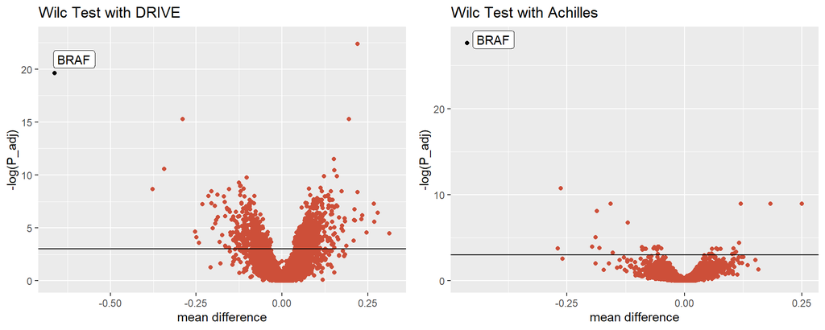

```r
plot.wilc.DRIVE.gene2 <- create_volcano_plot(test.results.gene2,"DRIVE","wilc",
                                       target.genes, show_sign_line=T)

plot.wilc.Achilles.gene2 <- create_volcano_plot(test.results.gene2,"Achilles",
                                                "wilc",target.genes)

grid.arrange(plot.wilc.DRIVE.gene2,plot.wilc.Achilles.gene2,ncol=2)
```

```r
rm(plot.wilc.DRIVE.gene2,plot.wilc.Achilles.gene2)
```

```r
significant.genes.table.DRIVE.gene2 <- create.significant.genes.table(
  test.results.gene2,"DRIVE","wilc")
significant.genes.table.Achilles.gene2 <- create.significant.genes.table(
  test.results.gene2,"Achilles","wilc")

knitr::kable(significant.genes.table.DRIVE.gene2, format = "html",
             table.attr = "style='width:50%;'",
             caption = "Significant Genes in DRIVE")
```

Table 6: Significant Genes in DRIVE

|  | gene | p_value | p_adj | log |
| --- | --- | --- | --- | --- |
| 5454 | PTPN11 | 0.0000000 | 0.0000000 | 22.378066 |
| 6104 | BRAF | 0.0000000 | 0.0000000 | 19.611794 |
| 6065 | SOS1 | 0.0000000 | 0.0000002 | 15.268958 |
| 7313 | PEA15 | 0.0000000 | 0.0000002 | 15.268958 |
| 6003 | NCF1C | 0.0000000 | 0.0000103 | 11.486883 |
| 4967 | PPP6C | 0.0000000 | 0.0000256 | 10.572580 |
| 1122 | ADH7 | 0.0000000 | 0.0000285 | 10.465122 |
| 1693 | ARID2 | 0.0000001 | 0.0000512 | 9.879934 |
| 5309 | ATP10A | 0.0000001 | 0.0000512 | 9.879934 |
| 3262 | HTR2C | 0.0000001 | 0.0000579 | 9.756649 |
| 5350 | PTK2 | 0.0000001 | 0.0000946 | 9.265446 |
| 1726 | FOXD4L1 | 0.0000002 | 0.0001270 | 8.971168 |
| 1366 | CBWD2&CBWD5&CBWD3&CBWD6 | 0.0000002 | 0.0001283 | 8.960925 |
| 6795 | SHOC2 | 0.0000003 | 0.0001546 | 8.774609 |
| 1715 | ELF1 | 0.0000003 | 0.0001631 | 8.721274 |
| 2220 | ICMT | 0.0000003 | 0.0001631 | 8.721274 |
| 6072 | SOX10 | 0.0000004 | 0.0001718 | 8.669378 |
| 881 | SLC5A11 | 0.0000004 | 0.0001737 | 8.658353 |
| 640 | METAP2 | 0.0000006 | 0.0002091 | 8.472871 |
| 929 | SH2D1B | 0.0000006 | 0.0002091 | 8.472871 |
| 5313 | VANGL2 | 0.0000005 | 0.0002091 | 8.472871 |
| 6325 | C4BPA | 0.0000006 | 0.0002091 | 8.472871 |
| 6565 | MAPKAPK3 | 0.0000006 | 0.0002091 | 8.472871 |
| 634 | CLP1 | 0.0000007 | 0.0002321 | 8.368169 |
| 6977 | TAF3 | 0.0000009 | 0.0002880 | 8.152568 |
| 986 | RXFP2 | 0.0000010 | 0.0003015 | 8.106586 |
| 2376 | RNF144B | 0.0000010 | 0.0003015 | 8.106586 |
| 2607 | PIPSL | 0.0000011 | 0.0003049 | 8.095489 |
| 770 | CHP1 | 0.0000012 | 0.0003280 | 8.022409 |
| 6871 | SPRY4 | 0.0000012 | 0.0003280 | 8.022409 |

[output cut: 1067 more lines]

```r
knitr::kable(significant.genes.table.Achilles.gene2, format = "html",
             table.attr = "style='width:50%;'",
             caption = "Significant Genes in Achilles")
```

Table 6: Significant Genes in Achilles

|  | gene | p_value | p_adj | log |
| --- | --- | --- | --- | --- |
| 1473 | BRAF | 0.00e+00 | 0.0000000 | 27.618258 |
| 8665 | MAPK1 | 0.00e+00 | 0.0000216 | 10.741368 |
| 6240 | GRB2 | 0.00e+00 | 0.0001323 | 8.930772 |
| 11115 | PEA15 | 0.00e+00 | 0.0001323 | 8.930772 |
| 12166 | PTPN11 | 0.00e+00 | 0.0001323 | 8.930772 |
| 13625 | SHOC2 | 0.00e+00 | 0.0001323 | 8.930772 |
| 9011 | MITF | 1.00e-07 | 0.0003038 | 8.099108 |
| 8633 | MAP2K1 | 5.00e-07 | 0.0011582 | 6.760858 |
| 14324 | SOX9 | 3.20e-06 | 0.0063512 | 5.059107 |
| 4899 | EXT1 | 7.00e-06 | 0.0123171 | 4.396770 |
| 2080 | CA3 | 1.43e-05 | 0.0194437 | 3.940233 |
| 3404 | CPED1 | 1.38e-05 | 0.0194437 | 3.940233 |
| 16887 | YRDC | 1.41e-05 | 0.0194437 | 3.940233 |
| 378 | AGBL3 | 1.71e-05 | 0.0201559 | 3.904259 |
| 17395 | ZNF592 | 1.68e-05 | 0.0201559 | 3.904259 |
| 2713 | CDK4 | 2.02e-05 | 0.0223035 | 3.803013 |
| 4381 | DUSP4 | 2.60e-05 | 0.0234906 | 3.751155 |
| 7732 | KIR2DL4 | 2.45e-05 | 0.0234906 | 3.751155 |
| 10611 | OR6B1 | 2.68e-05 | 0.0234906 | 3.751155 |
| 13090 | RTEL1 | 2.66e-05 | 0.0234906 | 3.751155 |
| 17434 | ZNF654 | 2.80e-05 | 0.0234906 | 3.751155 |
| 8042 | LAMB4 | 3.05e-05 | 0.0237127 | 3.741745 |
| 9017 | MKLN1 | 3.09e-05 | 0.0237127 | 3.741745 |
| 722 | AOC3 | 3.76e-05 | 0.0247481 | 3.699006 |
| 4365 | DUSP10 | 3.62e-05 | 0.0247481 | 3.699006 |
| 9020 | MKRN1 | 3.72e-05 | 0.0247481 | 3.699006 |
| 16614 | VPS53 | 3.79e-05 | 0.0247481 | 3.699006 |
| 11289 | PIGP | 4.09e-05 | 0.0257511 | 3.659277 |
| 7025 | IFRD1 | 4.65e-05 | 0.0273351 | 3.599583 |
| 9558 | NACA | 4.55e-05 | 0.0273351 | 3.599583 |
| 12354 | RABIF | 6.09e-05 | 0.0346427 | 3.362668 |
| 17013 | ZEB2 | 6.93e-05 | 0.0382089 | 3.264688 |
| 6011 | GNB1L | 8.18e-05 | 0.0424325 | 3.159842 |
| 16999 | ZDHHC19 | 8.00e-05 | 0.0424325 | 3.159842 |
| 15524 | TMEM222 | 8.83e-05 | 0.0445066 | 3.112119 |
| 5977 | GLYR1 | 9.60e-05 | 0.0457738 | 3.084044 |
| 11600 | POLR3B | 9.36e-05 | 0.0457738 | 3.084044 |

```r
rm(significant.genes.table.DRIVE.gene2,significant.genes.table.Achilles.gene2)
```

## Bayes Test

```r
plot.bayes.DRIVE.gene2 <- create_volcano_plot(test.results.gene2,"DRIVE","bayes",
                                       target.genes)

plot.bayes.Achilles.gene2 <- create_volcano_plot(test.results.gene2,"Achilles",
                                                "bayes",target.genes)

grid.arrange(plot.bayes.DRIVE.gene2,plot.bayes.Achilles.gene2,ncol=2)
```

[output not shown]

```r
rm(plot.bayes.DRIVE.gene2,plot.bayes.Achilles.gene2)
```

```r
significant.genes.table.DRIVE.gene2 <- create.significant.genes.table(
  test.results.gene2,"DRIVE","bayes")
significant.genes.table.Achilles.gene2 <- create.significant.genes.table(
  test.results.gene2,"Achilles","bayes")

knitr::kable(significant.genes.table.DRIVE.gene2, format = "html",
             table.attr = "style='width:50%;'",
             caption = "Significant Genes in DRIVE")
```

Table 7: Significant Genes in DRIVE

|  | gene | p_adj | log |
| --- | --- | --- | --- |
| 6104 | BRAF | 0.0000000 | 66.658172 |
| 6072 | SOX10 | 0.0000000 | 35.908052 |
| 7313 | PEA15 | 0.0000000 | 35.402285 |
| 4967 | PPP6C | 0.0000000 | 25.595642 |
| 3939 | MITF | 0.0000000 | 23.865323 |
| 1636 | DUSP4 | 0.0000000 | 22.430982 |
| 5128 | MAPK1 | 0.0000000 | 20.517237 |
| 4990 | TMEM55A | 0.0000001 | 15.945426 |
| 5454 | PTPN11 | 0.0000001 | 15.945426 |
| 1122 | ADH7 | 0.0000013 | 13.531367 |
| 5350 | PTK2 | 0.0000013 | 13.531367 |
| 6172 | TAF5 | 0.0000020 | 13.123044 |
| 6003 | NCF1C | 0.0000039 | 12.456091 |
| 750 | DUSP10 | 0.0000059 | 12.041407 |
| 4830 | PPM1G | 0.0000061 | 12.004935 |
| 7204 | ENC1 | 0.0000061 | 12.004935 |
| 975 | RHEBL1 | 0.0000072 | 11.841937 |
| 6065 | SOS1 | 0.0000072 | 11.841937 |
| 881 | SLC5A11 | 0.0000150 | 11.104494 |
| 929 | SH2D1B | 0.0000204 | 10.797811 |
| 5348 | TBC1D24 | 0.0000238 | 10.646644 |
| 6565 | MAPKAPK3 | 0.0000238 | 10.646644 |
| 634 | CLP1 | 0.0000301 | 10.410915 |
| 3262 | HTR2C | 0.0000301 | 10.410915 |
| 4882 | PPP2CB | 0.0000301 | 10.410915 |
| 1709 | SERPINB1 | 0.0000307 | 10.391868 |
| 5309 | ATP10A | 0.0000307 | 10.391868 |
| 6325 | C4BPA | 0.0000307 | 10.391868 |
| 6927 | FCRL4 | 0.0000307 | 10.391868 |
| 1547 | BMPER | 0.0000330 | 10.319582 |

[output cut: 1061 more lines]

```r
knitr::kable(significant.genes.table.Achilles.gene2, format = "html",
             table.attr = "style='width:50%;'",
             caption = "Significant Genes in Achilles")
```

Table 7: Significant Genes in Achilles

|  | gene | p_adj | log |
| --- | --- | --- | --- |
| 1473 | BRAF | 0.0000000 | 115.482009 |
| 8665 | MAPK1 | 0.0000000 | 36.930314 |
| 4381 | DUSP4 | 0.0000000 | 36.384071 |
| 11115 | PEA15 | 0.0000000 | 33.157522 |
| 14308 | SOX10 | 0.0000000 | 33.157522 |
| 9011 | MITF | 0.0000000 | 32.527041 |
| 14324 | SOX9 | 0.0000001 | 16.794475 |
| 8633 | MAP2K1 | 0.0000002 | 15.311874 |
| 6240 | GRB2 | 0.0000121 | 11.325027 |
| 12166 | PTPN11 | 0.0000131 | 11.242222 |
| 9788 | NFATC2 | 0.0001959 | 8.537813 |
| 17013 | ZEB2 | 0.0004204 | 7.774340 |
| 17395 | ZNF592 | 0.0012973 | 6.647454 |
| 8042 | LAMB4 | 0.0023425 | 6.056553 |
| 7732 | KIR2DL4 | 0.0028615 | 5.856417 |
| 16168 | TUBG1 | 0.0028615 | 5.856417 |
| 17434 | ZNF654 | 0.0028615 | 5.856417 |
| 378 | AGBL3 | 0.0036578 | 5.610882 |
| 13625 | SHOC2 | 0.0052886 | 5.242202 |
| 11713 | PPM1G | 0.0059028 | 5.132330 |
| 4188 | DNAJC13 | 0.0093032 | 4.677399 |
| 4899 | EXT1 | 0.0113790 | 4.475981 |
| 15053 | TCEB3 | 0.0126689 | 4.368608 |
| 4365 | DUSP10 | 0.0128759 | 4.352398 |
| 7025 | IFRD1 | 0.0141294 | 4.259497 |
| 11554 | PODXL | 0.0143175 | 4.246275 |
| 2080 | CA3 | 0.0143753 | 4.242246 |
| 2713 | CDK4 | 0.0143753 | 4.242246 |
| 5517 | FOXD4L5 | 0.0143753 | 4.242246 |
| 9558 | NACA | 0.0143753 | 4.242246 |

[output cut: 54 more lines]

```r
rm(significant.genes.table.DRIVE.gene2,significant.genes.table.Achilles.gene2,
   test.results.gene2)
```

# Data Analysis BRAF and BRAF

We do the same for BRAF and BRAF combined.

## Mean Differences

```r
test.results.gene12 <- calc.mean.diffs.and.p.values(dep.scores.DRIVE,
                                           dep.scores.Achilles,
                                           class.table.comb.DRIVE,
                                           class.table.comb.Achilles)

plots <- plot.mean.diffs(test.results.gene12)
grid.arrange(plots$DRIVE,plots$Achilles,ncol=2)
```

[output not shown]

```r
rm(class.table.comb.DRIVE,class.table.comb.Achilles,plots)
```

## Welch Test

```r
plot.welch.DRIVE.gene12 <- create_volcano_plot(test.results.gene12,"DRIVE",
                                              "welch",target.genes)

plot.welch.Achilles.gene12 <- create_volcano_plot(test.results.gene12,"Achilles",
                                                "welch",target.genes)

grid.arrange(plot.welch.DRIVE.gene12,plot.welch.Achilles.gene12,ncol=2)
```

[output not shown]

```r
rm(plot.welch.DRIVE.gene12,plot.welch.Achilles.gene12)
```

```r
significant.genes.table.DRIVE.gene12 <- create.significant.genes.table(
  test.results.gene12,"DRIVE","welch")
significant.genes.table.Achilles.gene12 <- create.significant.genes.table(
  test.results.gene12,"Achilles","welch")

knitr::kable(significant.genes.table.DRIVE.gene12, format = "html",
             table.attr = "style='width:50%;'",
             caption = "Significant Genes in DRIVE")
```

Table 8: Significant Genes in DRIVE

|  | gene | p_value | p_adj | log |
| --- | --- | --- | --- | --- |
| 5454 | PTPN11 | 0.0000000 | 0.0000004 | 14.644559 |
| 6065 | SOS1 | 0.0000000 | 0.0000007 | 14.179937 |
| 6104 | BRAF | 0.0000000 | 0.0000236 | 10.654276 |
| 6795 | SHOC2 | 0.0000001 | 0.0001642 | 8.714361 |
| 634 | CLP1 | 0.0000001 | 0.0001823 | 8.609843 |
| 1122 | ADH7 | 0.0000002 | 0.0002055 | 8.490227 |
| 1547 | BMPER | 0.0000002 | 0.0002055 | 8.490227 |
| 7580 | COL23A1 | 0.0000002 | 0.0002055 | 8.490227 |
| 986 | RXFP2 | 0.0000006 | 0.0003459 | 7.969467 |
| 1366 | CBWD2&CBWD5&CBWD3&CBWD6 | 0.0000005 | 0.0003459 | 7.969467 |
| 1693 | ARID2 | 0.0000005 | 0.0003459 | 7.969467 |
| 1726 | FOXD4L1 | 0.0000005 | 0.0003459 | 7.969467 |
| 2370 | CFAP65 | 0.0000004 | 0.0003459 | 7.969467 |
| 4137 | NFE2L2 | 0.0000007 | 0.0004206 | 7.773925 |
| 4967 | PPP6C | 0.0000008 | 0.0004226 | 7.769193 |
| 6003 | NCF1C | 0.0000008 | 0.0004226 | 7.769193 |
| 6072 | SOX10 | 0.0000010 | 0.0004453 | 7.716827 |
| 7897 | CDK1 | 0.0000010 | 0.0004453 | 7.716827 |
| 3828 | LYN | 0.0000015 | 0.0006114 | 7.399735 |
| 2386 | GABRB1 | 0.0000017 | 0.0006353 | 7.361344 |
| 5309 | ATP10A | 0.0000017 | 0.0006353 | 7.361344 |
| 5530 | RAF1 | 0.0000018 | 0.0006353 | 7.361344 |
| 308 | SF3A1 | 0.0000022 | 0.0007374 | 7.212340 |
| 3262 | HTR2C | 0.0000022 | 0.0007374 | 7.212340 |
| 86 | NT5C1B-RDH14&RDH14 | 0.0000025 | 0.0007714 | 7.167323 |
| 6325 | C4BPA | 0.0000025 | 0.0007714 | 7.167323 |
| 5877 | ANAPC1 | 0.0000030 | 0.0008751 | 7.041123 |
| 881 | SLC5A11 | 0.0000035 | 0.0009401 | 6.969499 |
| 6777 | PDGFD | 0.0000034 | 0.0009401 | 6.969499 |
| 7313 | PEA15 | 0.0000034 | 0.0009401 | 6.969499 |

[output cut: 882 more lines]

```r
knitr::kable(significant.genes.table.Achilles.gene12, format = "html",
             table.attr = "style='width:50%;'",
             caption = "Significant Genes in Achilles")
```

Table 8: Significant Genes in Achilles

|  | gene | p_value | p_adj | log |
| --- | --- | --- | --- | --- |
| 1473 | BRAF | 0.00e+00 | 0.0000000 | 17.743627 |
| 6240 | GRB2 | 1.00e-07 | 0.0003799 | 7.875705 |
| 8665 | MAPK1 | 1.00e-07 | 0.0003799 | 7.875705 |
| 12166 | PTPN11 | 1.00e-07 | 0.0003799 | 7.875705 |
| 13625 | SHOC2 | 1.00e-07 | 0.0003799 | 7.875705 |
| 4899 | EXT1 | 3.00e-06 | 0.0072669 | 4.924431 |
| 9011 | MITF | 3.00e-06 | 0.0072669 | 4.924431 |
| 14324 | SOX9 | 3.30e-06 | 0.0072669 | 4.924431 |
| 11115 | PEA15 | 3.90e-06 | 0.0075934 | 4.880482 |
| 16999 | ZDHHC19 | 4.90e-06 | 0.0086648 | 4.748487 |
| 14308 | SOX10 | 8.90e-06 | 0.0142912 | 4.248111 |
| 4381 | DUSP4 | 1.21e-05 | 0.0177572 | 4.030965 |
| 5393 | FGFR1 | 1.44e-05 | 0.0181259 | 4.010413 |
| 8633 | MAP2K1 | 1.44e-05 | 0.0181259 | 4.010413 |
| 17434 | ZNF654 | 1.80e-05 | 0.0211294 | 3.857091 |
| 2080 | CA3 | 2.05e-05 | 0.0225000 | 3.794238 |
| 10611 | OR6B1 | 2.24e-05 | 0.0225000 | 3.794238 |
| 11289 | PIGP | 2.30e-05 | 0.0225000 | 3.794238 |
| 7732 | KIR2DL4 | 2.62e-05 | 0.0234848 | 3.751400 |
| 13090 | RTEL1 | 2.66e-05 | 0.0234848 | 3.751400 |
| 14104 | SMAD4 | 3.54e-05 | 0.0271038 | 3.608083 |
| 16887 | YRDC | 3.53e-05 | 0.0271038 | 3.608083 |
| 17126 | ZNF148 | 3.27e-05 | 0.0271038 | 3.608083 |
| 8042 | LAMB4 | 4.86e-05 | 0.0342611 | 3.373746 |
| 9558 | NACA | 4.79e-05 | 0.0342611 | 3.373746 |
| 14040 | SLC7A6 | 5.74e-05 | 0.0389299 | 3.245992 |
| 3404 | CPED1 | 6.35e-05 | 0.0414709 | 3.182763 |
| 16614 | VPS53 | 6.63e-05 | 0.0417730 | 3.175505 |
| 722 | AOC3 | 7.37e-05 | 0.0420445 | 3.169027 |
| 9020 | MKRN1 | 7.33e-05 | 0.0420445 | 3.169027 |
| 17395 | ZNF592 | 7.39e-05 | 0.0420445 | 3.169027 |
| 378 | AGBL3 | 8.25e-05 | 0.0454361 | 3.091447 |
| 17013 | ZEB2 | 8.55e-05 | 0.0456686 | 3.086345 |
| 4903 | EXTL3 | 9.45e-05 | 0.0490324 | 3.015274 |
| 9800 | NFIX | 9.90e-05 | 0.0498765 | 2.998205 |

```r
rm(significant.genes.table.DRIVE.gene12,significant.genes.table.Achilles.gene12)
```

## Wilcoxon Test

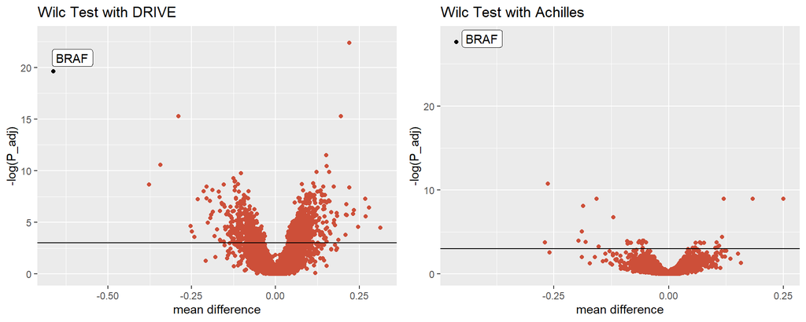

```r
plot.wilc.DRIVE.gene12 <- create_volcano_plot(test.results.gene12,"DRIVE","wilc",
                                       target.genes, show_sign_line=T)

plot.wilc.Achilles.gene12 <- create_volcano_plot(test.results.gene12,"Achilles",
                                                "wilc",target.genes)

grid.arrange(plot.wilc.DRIVE.gene12,plot.wilc.Achilles.gene12,ncol=2)
```

```r
rm(plot.wilc.DRIVE.gene12,plot.wilc.Achilles.gene12)
```

```r
significant.genes.table.DRIVE.gene12 <- create.significant.genes.table(
  test.results.gene12,"DRIVE","wilc")
significant.genes.table.Achilles.gene12 <- create.significant.genes.table(
  test.results.gene12,"Achilles","wilc")

knitr::kable(significant.genes.table.DRIVE.gene12, format = "html",
             table.attr = "style='width:50%;'",
             caption = "Significant Genes in DRIVE")
```

Table 9: Significant Genes in DRIVE

|  | gene | p_value | p_adj | log |
| --- | --- | --- | --- | --- |
| 5454 | PTPN11 | 0.0000000 | 0.0000000 | 22.378066 |
| 6104 | BRAF | 0.0000000 | 0.0000000 | 19.611794 |
| 6065 | SOS1 | 0.0000000 | 0.0000002 | 15.268958 |
| 7313 | PEA15 | 0.0000000 | 0.0000002 | 15.268958 |
| 6003 | NCF1C | 0.0000000 | 0.0000103 | 11.486883 |
| 4967 | PPP6C | 0.0000000 | 0.0000256 | 10.572580 |
| 1122 | ADH7 | 0.0000000 | 0.0000285 | 10.465122 |
| 1693 | ARID2 | 0.0000001 | 0.0000512 | 9.879934 |
| 5309 | ATP10A | 0.0000001 | 0.0000512 | 9.879934 |
| 3262 | HTR2C | 0.0000001 | 0.0000579 | 9.756649 |
| 5350 | PTK2 | 0.0000001 | 0.0000946 | 9.265446 |
| 1726 | FOXD4L1 | 0.0000002 | 0.0001270 | 8.971168 |
| 1366 | CBWD2&CBWD5&CBWD3&CBWD6 | 0.0000002 | 0.0001283 | 8.960925 |
| 6795 | SHOC2 | 0.0000003 | 0.0001546 | 8.774609 |
| 1715 | ELF1 | 0.0000003 | 0.0001631 | 8.721274 |
| 2220 | ICMT | 0.0000003 | 0.0001631 | 8.721274 |
| 6072 | SOX10 | 0.0000004 | 0.0001718 | 8.669378 |
| 881 | SLC5A11 | 0.0000004 | 0.0001737 | 8.658353 |
| 640 | METAP2 | 0.0000006 | 0.0002091 | 8.472871 |
| 929 | SH2D1B | 0.0000006 | 0.0002091 | 8.472871 |
| 5313 | VANGL2 | 0.0000005 | 0.0002091 | 8.472871 |
| 6325 | C4BPA | 0.0000006 | 0.0002091 | 8.472871 |
| 6565 | MAPKAPK3 | 0.0000006 | 0.0002091 | 8.472871 |
| 634 | CLP1 | 0.0000007 | 0.0002321 | 8.368169 |
| 6977 | TAF3 | 0.0000009 | 0.0002880 | 8.152568 |
| 986 | RXFP2 | 0.0000010 | 0.0003015 | 8.106586 |
| 2376 | RNF144B | 0.0000010 | 0.0003015 | 8.106586 |
| 2607 | PIPSL | 0.0000011 | 0.0003049 | 8.095489 |
| 770 | CHP1 | 0.0000012 | 0.0003280 | 8.022409 |
| 6871 | SPRY4 | 0.0000012 | 0.0003280 | 8.022409 |

[output cut: 1067 more lines]

```r
knitr::kable(significant.genes.table.Achilles.gene12, format = "html",
             table.attr = "style='width:50%;'",
             caption = "Significant Genes in Achilles")
```

Table 9: Significant Genes in Achilles

|  | gene | p_value | p_adj | log |
| --- | --- | --- | --- | --- |
| 1473 | BRAF | 0.00e+00 | 0.0000000 | 27.618258 |
| 8665 | MAPK1 | 0.00e+00 | 0.0000216 | 10.741368 |
| 6240 | GRB2 | 0.00e+00 | 0.0001323 | 8.930772 |
| 11115 | PEA15 | 0.00e+00 | 0.0001323 | 8.930772 |
| 12166 | PTPN11 | 0.00e+00 | 0.0001323 | 8.930772 |
| 13625 | SHOC2 | 0.00e+00 | 0.0001323 | 8.930772 |
| 9011 | MITF | 1.00e-07 | 0.0003038 | 8.099108 |
| 8633 | MAP2K1 | 5.00e-07 | 0.0011582 | 6.760858 |
| 14324 | SOX9 | 3.20e-06 | 0.0063512 | 5.059107 |
| 4899 | EXT1 | 7.00e-06 | 0.0123171 | 4.396770 |
| 2080 | CA3 | 1.43e-05 | 0.0194437 | 3.940233 |
| 3404 | CPED1 | 1.38e-05 | 0.0194437 | 3.940233 |
| 16887 | YRDC | 1.41e-05 | 0.0194437 | 3.940233 |
| 378 | AGBL3 | 1.71e-05 | 0.0201559 | 3.904259 |
| 17395 | ZNF592 | 1.68e-05 | 0.0201559 | 3.904259 |
| 2713 | CDK4 | 2.02e-05 | 0.0223035 | 3.803013 |
| 4381 | DUSP4 | 2.60e-05 | 0.0234906 | 3.751155 |
| 7732 | KIR2DL4 | 2.45e-05 | 0.0234906 | 3.751155 |
| 10611 | OR6B1 | 2.68e-05 | 0.0234906 | 3.751155 |
| 13090 | RTEL1 | 2.66e-05 | 0.0234906 | 3.751155 |
| 17434 | ZNF654 | 2.80e-05 | 0.0234906 | 3.751155 |
| 8042 | LAMB4 | 3.05e-05 | 0.0237127 | 3.741745 |
| 9017 | MKLN1 | 3.09e-05 | 0.0237127 | 3.741745 |
| 722 | AOC3 | 3.76e-05 | 0.0247481 | 3.699006 |
| 4365 | DUSP10 | 3.62e-05 | 0.0247481 | 3.699006 |
| 9020 | MKRN1 | 3.72e-05 | 0.0247481 | 3.699006 |
| 16614 | VPS53 | 3.79e-05 | 0.0247481 | 3.699006 |
| 11289 | PIGP | 4.09e-05 | 0.0257511 | 3.659277 |
| 7025 | IFRD1 | 4.65e-05 | 0.0273351 | 3.599583 |
| 9558 | NACA | 4.55e-05 | 0.0273351 | 3.599583 |
| 12354 | RABIF | 6.09e-05 | 0.0346427 | 3.362668 |
| 17013 | ZEB2 | 6.93e-05 | 0.0382089 | 3.264688 |
| 6011 | GNB1L | 8.18e-05 | 0.0424325 | 3.159842 |
| 16999 | ZDHHC19 | 8.00e-05 | 0.0424325 | 3.159842 |
| 15524 | TMEM222 | 8.83e-05 | 0.0445066 | 3.112119 |
| 5977 | GLYR1 | 9.60e-05 | 0.0457738 | 3.084044 |
| 11600 | POLR3B | 9.36e-05 | 0.0457738 | 3.084044 |

```r
rm(significant.genes.table.DRIVE.gene12,significant.genes.table.Achilles.gene12)
```

## Bayes Test

```r
plot.bayes.DRIVE.gene12 <- create_volcano_plot(test.results.gene12,"DRIVE",
                                               "bayes",target.genes)

plot.bayes.Achilles.gene12 <- create_volcano_plot(test.results.gene12,
                                                  "Achilles","bayes",
                                                  target.genes)

grid.arrange(plot.bayes.DRIVE.gene12,plot.bayes.Achilles.gene12,ncol=2)
```

[output not shown]

```r
rm(plot.bayes.DRIVE.gene12,plot.bayes.Achilles.gene12)
```

```r
significant.genes.table.DRIVE.gene12 <- create.significant.genes.table(
  test.results.gene12,"DRIVE","bayes")
significant.genes.table.Achilles.gene12 <- create.significant.genes.table(
  test.results.gene12,"Achilles","bayes")

knitr::kable(significant.genes.table.DRIVE.gene12, format = "html",
             table.attr = "style='width:50%;'",
             caption = "Significant Genes in DRIVE")
```

Table 10: Significant Genes in DRIVE

|  | gene | p_adj | log |
| --- | --- | --- | --- |
| 6104 | BRAF | 0.0000000 | 66.658172 |
| 6072 | SOX10 | 0.0000000 | 35.908052 |
| 7313 | PEA15 | 0.0000000 | 35.402285 |
| 4967 | PPP6C | 0.0000000 | 25.595642 |
| 3939 | MITF | 0.0000000 | 23.865323 |
| 1636 | DUSP4 | 0.0000000 | 22.430982 |
| 5128 | MAPK1 | 0.0000000 | 20.517237 |
| 4990 | TMEM55A | 0.0000001 | 15.945426 |
| 5454 | PTPN11 | 0.0000001 | 15.945426 |
| 1122 | ADH7 | 0.0000013 | 13.531367 |
| 5350 | PTK2 | 0.0000013 | 13.531367 |
| 6172 | TAF5 | 0.0000020 | 13.123044 |
| 6003 | NCF1C | 0.0000039 | 12.456091 |
| 750 | DUSP10 | 0.0000059 | 12.041407 |
| 4830 | PPM1G | 0.0000061 | 12.004935 |
| 7204 | ENC1 | 0.0000061 | 12.004935 |
| 975 | RHEBL1 | 0.0000072 | 11.841937 |
| 6065 | SOS1 | 0.0000072 | 11.841937 |
| 881 | SLC5A11 | 0.0000150 | 11.104494 |
| 929 | SH2D1B | 0.0000204 | 10.797811 |
| 5348 | TBC1D24 | 0.0000238 | 10.646644 |
| 6565 | MAPKAPK3 | 0.0000238 | 10.646644 |
| 634 | CLP1 | 0.0000301 | 10.410915 |
| 3262 | HTR2C | 0.0000301 | 10.410915 |
| 4882 | PPP2CB | 0.0000301 | 10.410915 |
| 1709 | SERPINB1 | 0.0000307 | 10.391868 |
| 5309 | ATP10A | 0.0000307 | 10.391868 |
| 6325 | C4BPA | 0.0000307 | 10.391868 |
| 6927 | FCRL4 | 0.0000307 | 10.391868 |
| 1547 | BMPER | 0.0000330 | 10.319582 |

[output cut: 1061 more lines]

```r
knitr::kable(significant.genes.table.Achilles.gene12, format = "html",
             table.attr = "style='width:50%;'",
             caption = "Significant Genes in Achilles")
```

Table 10: Significant Genes in Achilles

|  | gene | p_adj | log |
| --- | --- | --- | --- |
| 1473 | BRAF | 0.0000000 | 115.482009 |
| 8665 | MAPK1 | 0.0000000 | 36.930314 |
| 4381 | DUSP4 | 0.0000000 | 36.384071 |
| 11115 | PEA15 | 0.0000000 | 33.157522 |
| 14308 | SOX10 | 0.0000000 | 33.157522 |
| 9011 | MITF | 0.0000000 | 32.527041 |
| 14324 | SOX9 | 0.0000001 | 16.794475 |
| 8633 | MAP2K1 | 0.0000002 | 15.311874 |
| 6240 | GRB2 | 0.0000121 | 11.325027 |
| 12166 | PTPN11 | 0.0000131 | 11.242222 |
| 9788 | NFATC2 | 0.0001959 | 8.537813 |
| 17013 | ZEB2 | 0.0004204 | 7.774340 |
| 17395 | ZNF592 | 0.0012973 | 6.647454 |
| 8042 | LAMB4 | 0.0023425 | 6.056553 |
| 7732 | KIR2DL4 | 0.0028615 | 5.856417 |
| 16168 | TUBG1 | 0.0028615 | 5.856417 |
| 17434 | ZNF654 | 0.0028615 | 5.856417 |
| 378 | AGBL3 | 0.0036578 | 5.610882 |
| 13625 | SHOC2 | 0.0052886 | 5.242202 |
| 11713 | PPM1G | 0.0059028 | 5.132330 |
| 4188 | DNAJC13 | 0.0093032 | 4.677399 |
| 4899 | EXT1 | 0.0113790 | 4.475981 |
| 15053 | TCEB3 | 0.0126689 | 4.368608 |
| 4365 | DUSP10 | 0.0128759 | 4.352398 |
| 7025 | IFRD1 | 0.0141294 | 4.259497 |
| 11554 | PODXL | 0.0143175 | 4.246275 |
| 2080 | CA3 | 0.0143753 | 4.242246 |
| 2713 | CDK4 | 0.0143753 | 4.242246 |
| 5517 | FOXD4L5 | 0.0143753 | 4.242246 |
| 9558 | NACA | 0.0143753 | 4.242246 |

[output cut: 54 more lines]

```r
rm(significant.genes.table.DRIVE.gene12,significant.genes.table.Achilles.gene12,
   test.results.gene12)
```